# cleanprep

### Clean and Preparation Demonstration

#### Importing Data

Import the Titanic dataset. The data is attached to a package. This is text file where data entries are separated by commas.

```r
titanic = titanic::titanic_train
```

#### Examining the Data

Structure and summary of the dataset.

```r
str(titanic)
```

```
'data.frame':   891 obs. of  12 variables:
 $ PassengerId: int  1 2 3 4 5 6 7 8 9 10 ...
 $ Survived   : int  0 1 1 1 0 0 0 0 1 1 ...
 $ Pclass     : int  3 1 3 1 3 3 1 3 3 2 ...
 $ Name       : chr  "Braund, Mr. Owen Harris" "Cumings, Mrs. John Bradley (Florence Briggs Thayer)" "Heikkinen, Miss. Laina" "Futrelle, Mrs. Jacques Heath (Lily May Peel)" ...
 $ Sex        : chr  "male" "female" "female" "female" ...
 $ Age        : num  22 38 26 35 35 NA 54 2 27 14 ...
 $ SibSp      : int  1 1 0 1 0 0 0 3 0 1 ...
 $ Parch      : int  0 0 0 0 0 0 0 1 2 0 ...
 $ Ticket     : chr  "A/5 21171" "PC 17599" "STON/O2. 3101282" "113803" ...
 $ Fare       : num  7.25 71.28 7.92 53.1 8.05 ...
 $ Cabin      : chr  "" "C85" "" "C123" ...
 $ Embarked   : chr  "S" "C" "S" "S" ...
```

```r
summary(titanic)
```

```
  PassengerId       Survived          Pclass          Name
 Min.   :  1.0   Min.   :0.0000   Min.   :1.000   Length:891
 1st Qu.:223.5   1st Qu.:0.0000   1st Qu.:2.000   Class :character
 Median :446.0   Median :0.0000   Median :3.000   Mode  :character
 Mean   :446.0   Mean   :0.3838   Mean   :2.309
 3rd Qu.:668.5   3rd Qu.:1.0000   3rd Qu.:3.000
 Max.   :891.0   Max.   :1.0000   Max.   :3.000

     Sex                 Age            SibSp           Parch
 Length:891         Min.   : 0.42   Min.   :0.000   Min.   :0.0000
 Class :character   1st Qu.:20.12   1st Qu.:0.000   1st Qu.:0.0000
 Mode  :character   Median :28.00   Median :0.000   Median :0.0000
                    Mean   :29.70   Mean   :0.523   Mean   :0.3816
                    3rd Qu.:38.00   3rd Qu.:1.000   3rd Qu.:0.0000
                    Max.   :80.00   Max.   :8.000   Max.   :6.0000
                    NA's   :177
    Ticket               Fare           Cabin             Embarked
 Length:891         Min.   :  0.00   Length:891         Length:891
 Class :character   1st Qu.:  7.91   Class :character   Class :character
 Mode  :character   Median : 14.45   Mode  :character   Mode  :character
                    Mean   : 32.20
                    3rd Qu.: 31.00
                    Max.   :512.33
```

Things to notice:  
**1.** Notice how missing data is displayed in the summary. Be careful because people do NOT always record missing values in the same manner!! How do we deal with missing data?

**2.** Categorical variables have not been automatically converted to factors. We can manually convert them.

#### Cleaning the Data

Variable Clean-up. Here we use the following functions:

- select: To remove (delete) unneeded columns
- as_factor: Convert categorical variables to “factors”
- fct_recode: Rename factor “levels”

```r
titanic = titanic %>% select(-PassengerId, -Name, -Fare, -Cabin, -Ticket, -Embarked)

titanic = titanic %>% mutate(Survived = as_factor(Survived)) %>%
  mutate(Survived = fct_recode(Survived, "No" = "0", "Yes" = "1" )) %>%
  mutate(Pclass = as_factor(Pclass)) %>% mutate(Sex = as_factor(Sex))
str(titanic)
```

```
'data.frame':   891 obs. of  6 variables:
 $ Survived: Factor w/ 2 levels "No","Yes": 1 2 2 2 1 1 1 1 2 2 ...
 $ Pclass  : Factor w/ 3 levels "1","2","3": 3 1 3 1 3 3 1 3 3 2 ...
 $ Sex     : Factor w/ 2 levels "male","female": 1 2 2 2 1 1 1 1 2 2 ...
 $ Age     : num  22 38 26 35 35 NA 54 2 27 14 ...
 $ SibSp   : int  1 1 0 1 0 0 0 3 0 1 ...
 $ Parch   : int  0 0 0 0 0 0 0 1 2 0 ...
```

Missingness (there are MANY ways to visualize missing data in a dataset, here’s one way). Here we use “aggr” function from the VIM package.

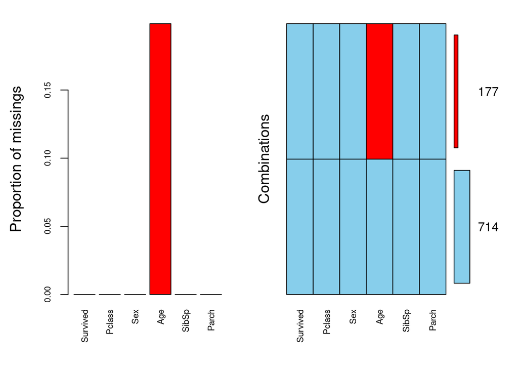

```r
vim_plot = aggr(titanic, numbers = TRUE, prop = c(TRUE, FALSE),cex.axis=.7)
```

```r
#impute age
set.seed(12345)
imp_age = mice(titanic, m=5, method='pmm', printFlag=FALSE) #imputes age
summary(imp_age)
```

```
Class: mids
Number of multiple imputations:  5
Imputation methods:
Survived   Pclass      Sex      Age    SibSp    Parch
      ""       ""       ""    "pmm"       ""       ""
PredictorMatrix:
         Survived Pclass Sex Age SibSp Parch
Survived        0      1   1   1     1     1
Pclass          1      0   1   1     1     1
Sex             1      1   0   1     1     1
Age             1      1   1   0     1     1
SibSp           1      1   1   1     0     1
Parch           1      1   1   1     1     0
```

Fill in missing values with combined imputed values

```r
titanic_complete = complete(imp_age)
summary(titanic_complete)
```

```
 Survived  Pclass      Sex           Age            SibSp
 No :549   1:216   male  :577   Min.   : 0.42   Min.   :0.000
 Yes:342   2:184   female:314   1st Qu.:20.00   1st Qu.:0.000
           3:491                Median :29.00   Median :0.000
                                Mean   :29.86   Mean   :0.523
                                3rd Qu.:39.00   3rd Qu.:1.000
                                Max.   :80.00   Max.   :8.000
     Parch
 Min.   :0.0000
 1st Qu.:0.0000
 Median :0.0000
 Mean   :0.3816
 3rd Qu.:0.0000
 Max.   :6.0000
```

#### Visualization

Look at visuals of each variable versus the response variable “survived”.

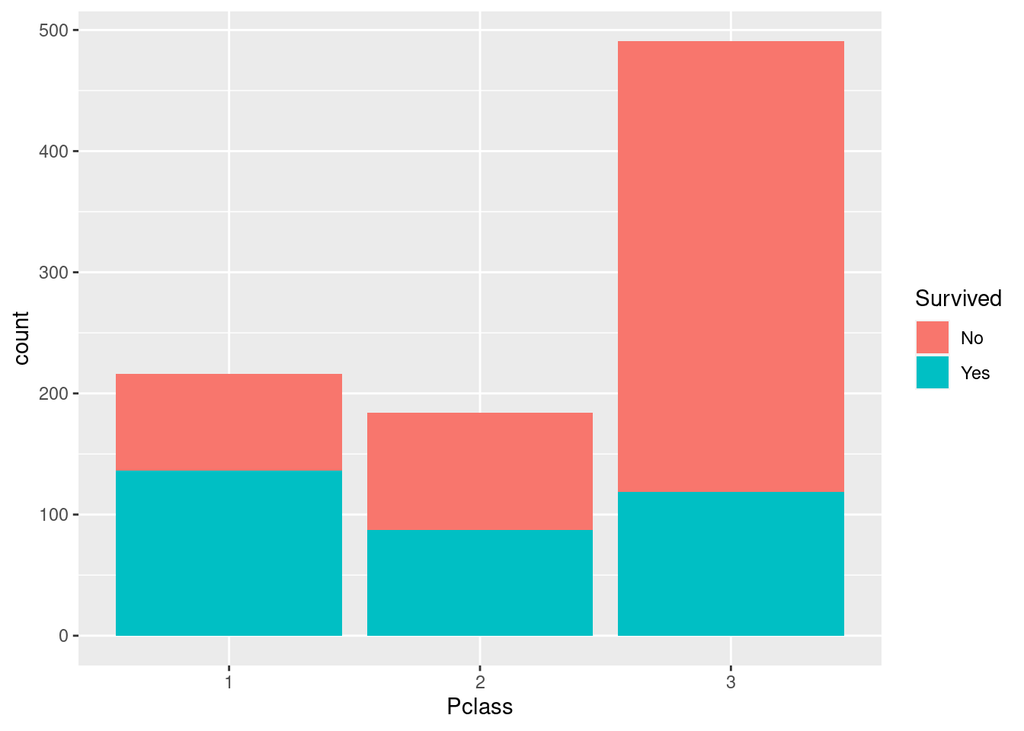

```r
ggplot(titanic, aes(x=Pclass, fill = Survived)) + geom_bar()
```

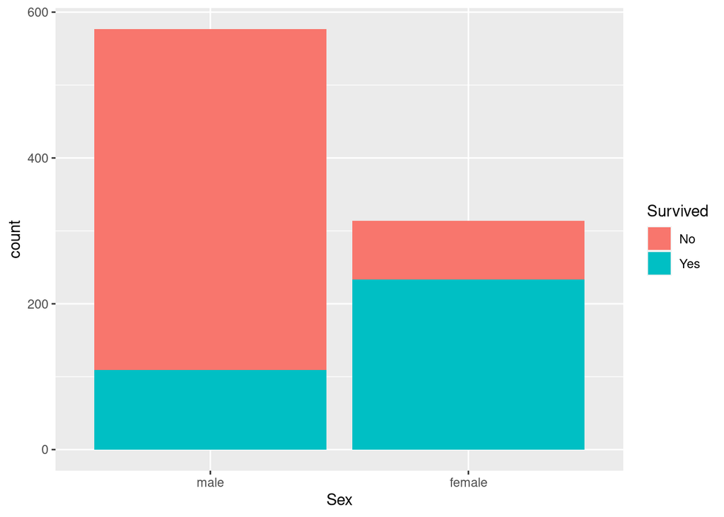

```r
ggplot(titanic, aes(x=Sex, fill = Survived)) + geom_bar()
```

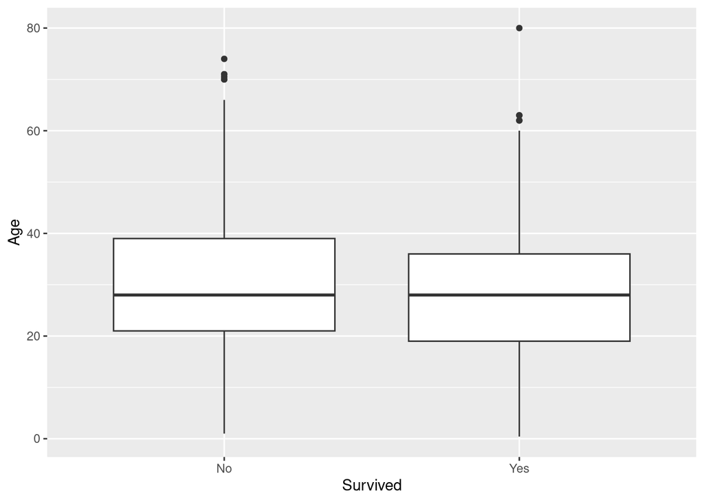

```r
ggplot(titanic, aes(x=Survived, y = Age)) + geom_boxplot()
```

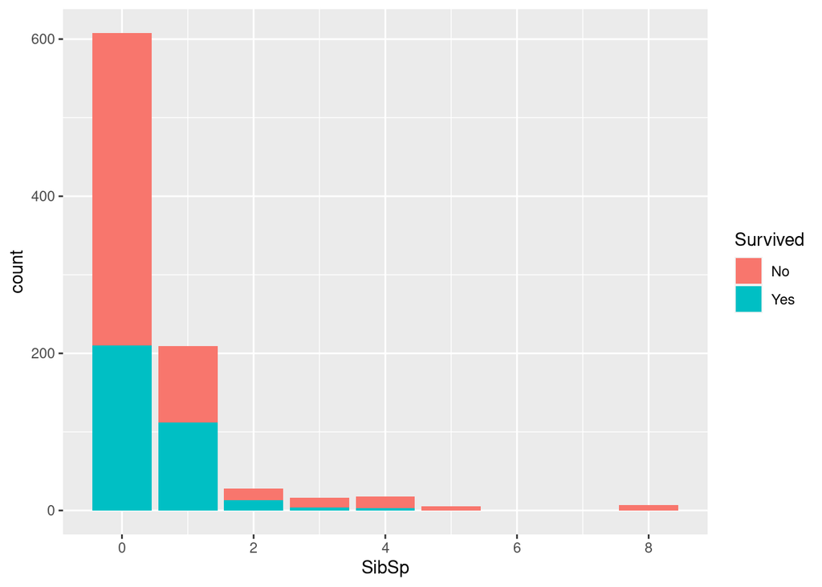

```r
ggplot(titanic, aes(x=SibSp, fill=Survived)) + geom_bar()
```

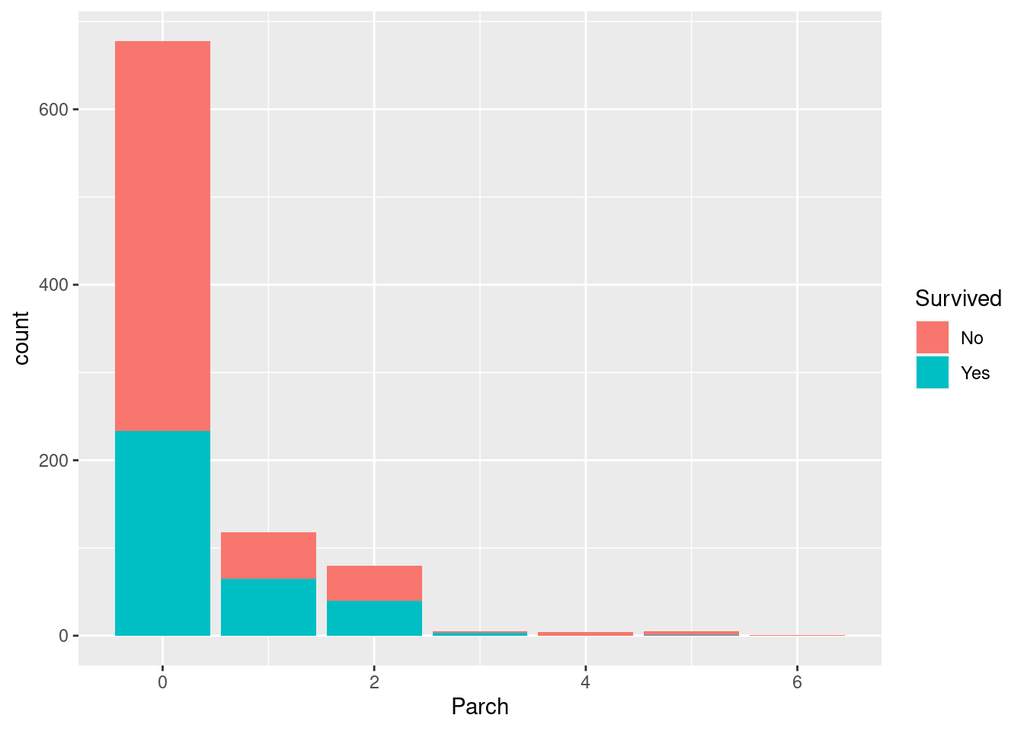

```r
ggplot(titanic, aes(x=Parch, fill=Survived)) + geom_bar()
```

#### Arranging Plots in a Grid

You may find it desirable (to save space in your document) to arrange plots in a grid.

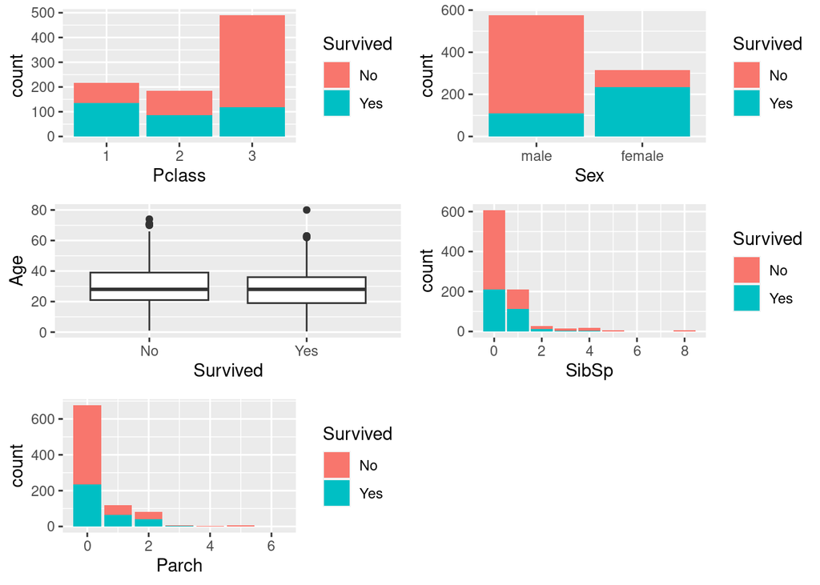

```r
p1 = ggplot(titanic, aes(x=Pclass, fill = Survived)) + geom_bar()
p2 = ggplot(titanic, aes(x=Sex, fill = Survived)) + geom_bar()
p3 = ggplot(titanic, aes(x=Survived, y = Age)) + geom_boxplot()
p4 = ggplot(titanic, aes(x=SibSp, fill=Survived)) + geom_bar()
p5 = ggplot(titanic, aes(x=Parch, fill=Survived)) + geom_bar()
grid.arrange(p1,p2,p3,p4,p5, ncol = 2)
```

An alternative using the patchwork package.

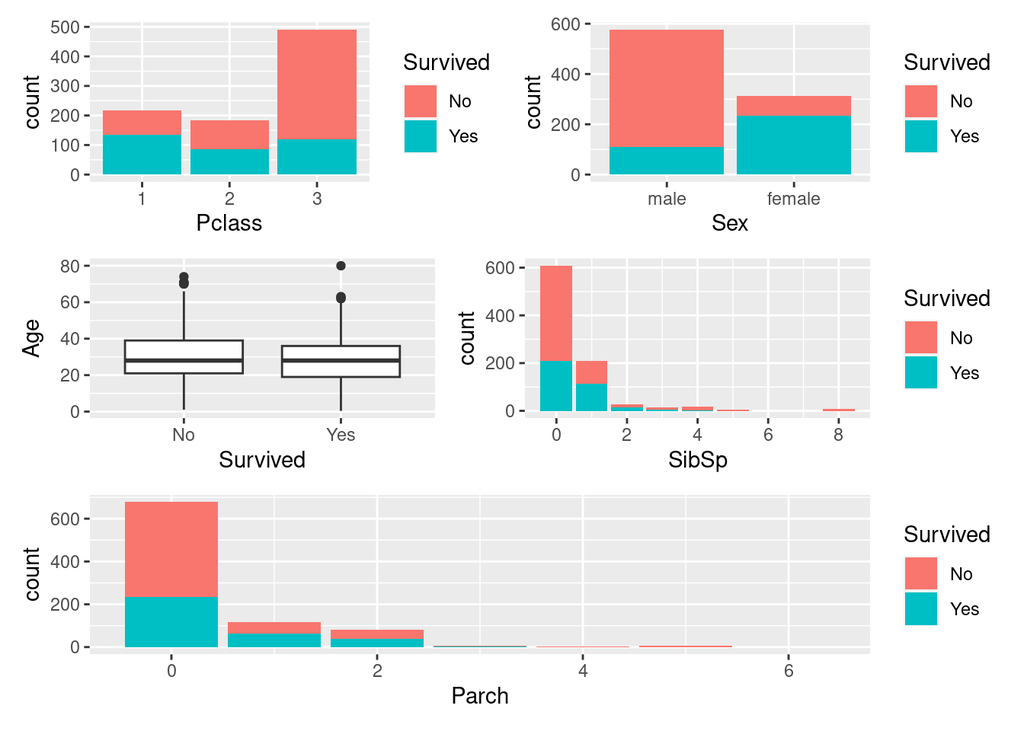

```r
(p1 | p2) / (p3 | p4) / p5
```

#### Rendering/Knitting

Convert your Quarto work into an HTML or Word file by clicking Render and selecting HTML or Word. Rendering can take awhile! When rendering, R is re-running all of your code. If you have code that takes a long time to execute, it will take a long time to render!

#### Exporting Files from RStudio Cloud

To save a file from your RStudio Cloud project to your local computer (for example, in order to submit work for homework or exams), start by going to the Files pane (lower right of RStudio). Click the box next to the file you want to export. Click the gear icon next to “More” in the File pane area and then click “Export”. You will then be able to save the file to your computer.